# Subject-wise Quality Check

Kianté A. Fernandez

3/31/2020

We want to know:

**Only considering the task data, what are some characteristics that would make us skeptical of a set of observations from a given subject?**

## Observation Counts

Let’s start by taking a look at how many observations we have for each of the subjects.

```
##          No Yes
## 01rSsifR 53  22
## 19x3QrYn 10  65
## 2OsQQK3Z 40  35
## 2X1xhDjv 55  20
## 363Bpm6B 61  14
## 3eryCPLE 63  12
## 3FgQya4U 46  29
## 5ORauwUN 61  14
## 9TqGmj5u 58  17
## aPO6mMV7 20  55
## aV7OwysJ  4  71
## aZKHUZcI 25  50
## b84d6o3e  1  74
## dbNJPQT8 57  18
## dtN3tumi 13  62
## EjJX2xQw 69   6
## FcP5oD0l  8  67
## fqwC59NW 25  50
## FQZs26ef 32  43
## Gd2AL9OU 48  27
## gd3OIQ0t 68   7
## HFnyrGqQ 55  20
## IcxzdmfO 60  15
## jj8CVQyJ 36  39
## JNSeqF0i 48  27
## JvHLkdac 48  27
## kAMrs3cO 67   8
## L3dvhd7L 75  75
## lkC8NMWO 47  28
## LvFtBOzA 39  36
## m7EvsSNN 57  18
## M8TKy4LM 14  61
## mkdGXT4f 61  14
## naXDwzU1 63  12
## nB8WmX4K 58  17
## ndIlEBE6 50  25
## nyE1r1yE 35  40
## oEFhKj3D 45  30
## rbbgh7cl 57  18
## rN09W2Hk 57  18
## ssV5bSIv 45  30
## T3MThDhj 53  22
## TwPqcu7u 50  25
## vQYBZ8Qe 42  33
## vsJDnjLj 59  16
## w5DG17p0 38  37
## w6OM7v6w  2  73
## WN0VE4FZ 73   2
## YgSlD5mK 30  45
## Yndl6lBy 40  35
## ZAtx6CUR  2  73
## zeRcEHIn 38  37
## ZhxK8ZH8 66   9
## zrwNx8or 28  47
```

```
##        No             Yes
##  Min.   : 1.00   Min.   : 2.00
##  1st Qu.:32.75   1st Qu.:17.25
##  Median :48.00   Median :27.50
##  Mean   :43.61   Mean   :32.78
##  3rd Qu.:58.00   3rd Qu.:44.50
##  Max.   :75.00   Max.   :75.00
```

This does not seem to tell us much. We can notice that some people have distributions that are quite asymmetrical, but we cannot see any particular reason that may explain these distributions.

## Response Time

If we are only considering the task data, one of the first things we can look at is how long subjects took. Luckily, we gathered this data.

Let’s take a look at the distribution in a summary table first.

```r
RT = select_(cleanPilot, "rt")
summary(RT)
```

```
##        rt
##  Min.   :      0.0
##  1st Qu.:    627.6
##  Median :    979.3
##  Mean   :   2424.4
##  3rd Qu.:   1595.2
##  Max.   :2858690.4
```

Here **rt** represents the amount of time elapsed from stimulus onset (when the visual analog options appear) to when the subject makes a decision measured in milliseconds.

Let’s look at the extremes first:

- Oddly, it seems like someone was able to answer at 0.00. This means that during this trial, a response was imputed faster than our measurement tool could record; sounds like we found a bot!
- On the other end we have a trial that was over 45 mins. Seeing as we ask our subjects to respond quickly this looks like someone walked away from the task or something.

I am less confident that we can interpret the mean here given that our task does occur over time. So, we can account for this by grouping our data by trial. That way our nested observations are grouped by trial and we can visualize changes in average response time across subjects by trial.

Here is a visualization of each trial’s average response time before removing any of the potential bot data:

```
## geom_path: Each group consists of only one observation. Do you need to adjust
## the group aesthetic?
```

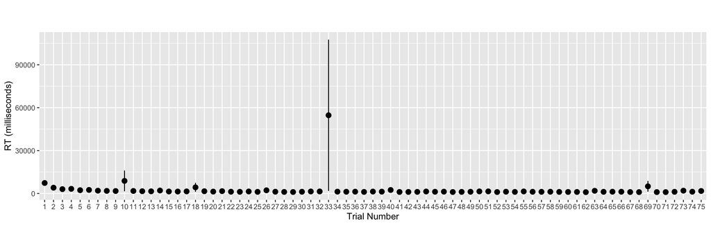

On the x axis we have trials 1 to 75* and on the y axis we have average rt.

You can see outliers are really doing a number on what we are able to see here. However, it is clear that we do have some observations that are far too large.

I did not want to make too many choices related to the lower bound, but it should not take anyone over a min per trial. So I will take some liberties for the sake of spotting some potential bots and set the bounds to 1min and 1/4th a second.

```r
cleanPilot = filter(cleanPilot, rt <= 60000 & rt >= 250)

table(cleanPilot$user_id)
```

```
##
## 01rSsifR 19x3QrYn 2OsQQK3Z 2X1xhDjv 363Bpm6B 3eryCPLE 3FgQya4U 5ORauwUN
##       75       75       75       75       75       75       75       75
## 9TqGmj5u aPO6mMV7 aV7OwysJ aZKHUZcI b84d6o3e dbNJPQT8 dtN3tumi EjJX2xQw
##       74       74       75       75       74       75       75       75
## FcP5oD0l fqwC59NW FQZs26ef Gd2AL9OU gd3OIQ0t HFnyrGqQ IcxzdmfO jj8CVQyJ
##       75       75       75       75       75       75       75       58
## JNSeqF0i JvHLkdac kAMrs3cO L3dvhd7L lkC8NMWO LvFtBOzA m7EvsSNN M8TKy4LM
##       75       75       75       75       75       75       75       75
## mkdGXT4f naXDwzU1 nB8WmX4K ndIlEBE6 nyE1r1yE oEFhKj3D rbbgh7cl rN09W2Hk
##       75       75       75       75       62       18       75       75
## ssV5bSIv T3MThDhj TwPqcu7u vQYBZ8Qe vsJDnjLj w5DG17p0 w6OM7v6w WN0VE4FZ
##       52       75       75       75       75       75       73       75
## YgSlD5mK Yndl6lBy ZAtx6CUR zeRcEHIn ZhxK8ZH8 zrwNx8or
##       75       56       75       75       62       75
```

This is a sanity check that I am filtering trials.

Here you can see several subjects have lost so trials to these bounds we set. Let’s take a look at the data now without these subjects.

```
##
## 01rSsifR 19x3QrYn 2OsQQK3Z 2X1xhDjv 363Bpm6B 3eryCPLE 3FgQya4U 5ORauwUN
##       75       75       75       75       75       75       75       75
## aV7OwysJ aZKHUZcI dbNJPQT8 dtN3tumi EjJX2xQw FcP5oD0l fqwC59NW FQZs26ef
##       75       75       75       75       75       75       75       75
## Gd2AL9OU gd3OIQ0t HFnyrGqQ IcxzdmfO JNSeqF0i JvHLkdac kAMrs3cO L3dvhd7L
##       75       75       75       75       75       75       75       75
## lkC8NMWO LvFtBOzA m7EvsSNN M8TKy4LM mkdGXT4f naXDwzU1 nB8WmX4K ndIlEBE6
##       75       75       75       75       75       75       75       75
## rbbgh7cl rN09W2Hk T3MThDhj TwPqcu7u vQYBZ8Qe vsJDnjLj w5DG17p0 WN0VE4FZ
##       75       75       75       75       75       75       75       75
## YgSlD5mK ZAtx6CUR zeRcEHIn zrwNx8or
##       75       75       75       75
```

```
##    user_id                rt           trial_index
##  Length:3300        Min.   :  305.1   1      :  44
##  Class :character   1st Qu.:  706.8   2      :  44
##  Mode  :character   Median : 1076.4   3      :  44
##                     Mean   : 1593.5   4      :  44
##                     3rd Qu.: 1709.9   5      :  44
##                     Max.   :44883.0   6      :  44
##                                       (Other):3036
```

Looks like we are at 44 subjects now.

Here the new plot:

```
## geom_path: Each group consists of only one observation. Do you need to adjust
## the group aesthetic?
```

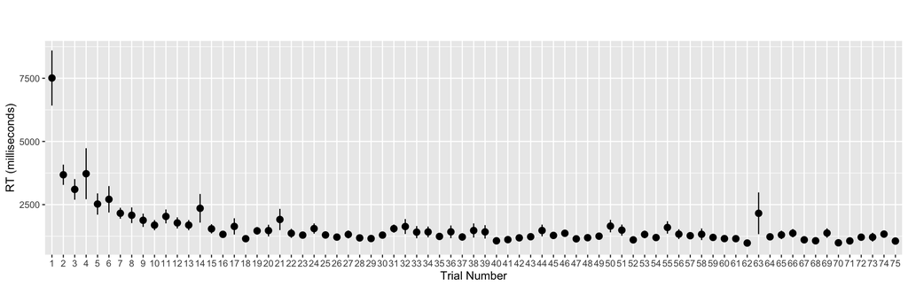

Just only looking at the visualization, we can already see what we expect: People take some time figuring out what is being asked and get faster over time.

## Closing thoughts

We could also look at key press behavior, though I am not sure how we would model this or learn who was bunk from this data other than a seeing someone only clicked one button the whole time (no one did).

If we consider the first attention check, we knock off a few more and end with **39 subjects**